# Analysis of Ischemic Heart Disease Costs

Group 1

2026-03-31

```r
# Load necessary libraries
library(tidyverse)
library(broom)
library(car)
library(GGally)     #
```

```r
# Set global options for chunks
knitr::opts_chunk$set(echo = TRUE, fig.width = 8, fig.height = 5)
```

```r
# Define the column names based on the textbook appendix
variable_names <- c("ID", "TotalCost", "Age", "Gender", "Interventions",
                   "Drugs", "ERVisits", "Complications", "Comorbidities", "Duration")

# Load the data
# Note: Ensure APPENC09.txt is in your working directory
# We use read_table as it handles multiple spaces between columns
heart_data <- read_table("C:/Users/engungi/Downloads/APPENC09.txt", col_names = variable_names, comment = "[")
# Basic Data Cleaning
heart_data <- heart_data %>%
  mutate(Gender = as.factor(Gender)) %>% # Set Gender as a categorical factor
  filter(!is.na(TotalCost))             # Ensure no empty rows were imported

# Preview the data
print(head(heart_data))
```

```
## # A tibble: 6 × 10
##      ID TotalCost   Age Gender Interventions Drugs ERVisits Complications
##   <dbl>     <dbl> <dbl> <fct>          <dbl> <dbl>    <dbl>         <dbl>
## 1     1      179.    63 0                  2     1        4             0
## 2     2      319     59 0                  2     0        6             0
## 3     3     9311.    62 0                 17     0        2             0
## 4     4      281.    60 1                  9     0        7             0
## 5     5    18727.    55 0                  5     2        7             0
## 6     6      453.    66 0                  1     0        3             0
## # ℹ 2 more variables: Comorbidities <dbl>, Duration <dbl>
```

This report analyzes a dataset of 788 subscribers who made claims related to Ischemic Heart Disease between January 1, 1998, and December 31, 1999. Our primary goal is to model the Total Cost of services as a response variable to understand which factors most significantly drive medical expenses.

## Numerical Summaries

This chunk provides a summary of the data, showing the range, mean, and any missing values.

```r
# Get descriptive statistics for all variables
print(summary(heart_data))
```

```
##        ID          TotalCost            Age        Gender  Interventions
##  Min.   :  1.0   Min.   :    0.0   Min.   :24.00   0:608   Min.   : 0.000
##  1st Qu.:197.8   1st Qu.:  161.1   1st Qu.:55.00   1:180   1st Qu.: 1.000
##  Median :394.5   Median :  507.2   Median :60.00           Median : 3.000
##  Mean   :394.5   Mean   : 2800.0   Mean   :58.72           Mean   : 4.707
##  3rd Qu.:591.2   3rd Qu.: 1905.5   3rd Qu.:64.00           3rd Qu.: 6.000
##  Max.   :788.0   Max.   :52664.9   Max.   :70.00           Max.   :47.000
##      Drugs           ERVisits      Complications     Comorbidities
##  Min.   :0.0000   Min.   : 0.000   Min.   :0.00000   Min.   : 0.000
##  1st Qu.:0.0000   1st Qu.: 2.000   1st Qu.:0.00000   1st Qu.: 0.000
##  Median :0.0000   Median : 3.000   Median :0.00000   Median : 1.000
##  Mean   :0.4467   Mean   : 3.425   Mean   :0.05711   Mean   : 3.766
##  3rd Qu.:0.0000   3rd Qu.: 5.000   3rd Qu.:0.00000   3rd Qu.: 5.000
##  Max.   :9.0000   Max.   :20.000   Max.   :3.00000   Max.   :60.000
##     Duration
##  Min.   :  0.00
##  1st Qu.: 41.75
##  Median :165.50
##  Mean   :164.03
##  3rd Qu.:281.00
##  Max.   :372.00
```

```r
# Total count of NAs in each column
heart_data %>%
  summarise(across(everything(), ~ sum(is.na(.))))
```

```
## # A tibble: 1 × 10
##      ID TotalCost   Age Gender Interventions Drugs ERVisits Complications
##   <int>     <int> <int>  <int>         <int> <int>    <int>         <int>
## 1     0         0     0      0             0     0        0             0
## # ℹ 2 more variables: Comorbidities <int>, Duration <int>
```

```r
# Check the structure to ensure data types are correct
print(str(heart_data))
```

```
## tibble [788 × 10] (S3: tbl_df/tbl/data.frame)
##  $ ID           : num [1:788] 1 2 3 4 5 6 7 8 9 10 ...
##  $ TotalCost    : num [1:788] 179 319 9311 281 18727 ...
##  $ Age          : num [1:788] 63 59 62 60 55 66 64 45 68 64 ...
##  $ Gender       : Factor w/ 2 levels "0","1": 1 1 1 2 1 1 2 2 1 2 ...
##  $ Interventions: num [1:788] 2 2 17 9 5 1 2 3 6 3 ...
##  $ Drugs        : num [1:788] 1 0 0 0 2 0 0 0 2 0 ...
##  $ ERVisits     : num [1:788] 4 6 2 7 7 3 3 5 5 2 ...
##  $ Complications: num [1:788] 0 0 0 0 0 0 0 0 0 0 ...
##  $ Comorbidities: num [1:788] 3 0 5 2 0 4 1 1 4 0 ...
##  $ Duration     : num [1:788] 300 120 353 332 18 296 247 82 334 85 ...
## NULL
```

## 2. Visualizing the Response Variable (Total Cost)

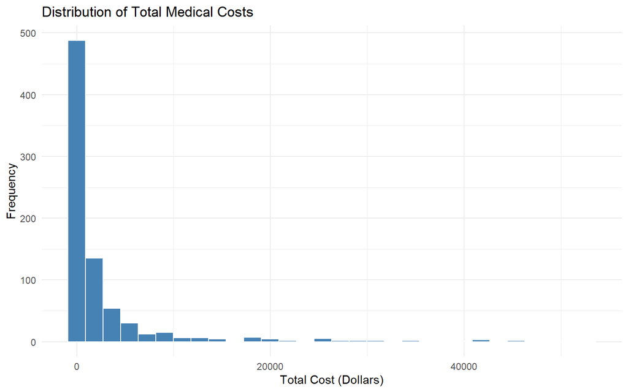

```r
# Histogram of Total Cost
ggplot(heart_data, aes(x = TotalCost)) +
  geom_histogram(fill = "steelblue", color = "white", bins = 30) +
  labs(title = "Distribution of Total Medical Costs",
       x = "Total Cost (Dollars)",
       y = "Frequency") +
  theme_minimal()
```

Positive Skew: The data is heavily right-skewed (positively skewed), with a massive clump of observations near the zero-to-low dollar range and a very long tail extending toward high costs.

Frequency Breakdown: The majority of the 788 subscribers incurred relatively low costs (under $\$5,000$), but a small number of “high-cost” patients incurred claims exceeding $\$20,000$, with some reaching over $\$40,000$.

## 3. Bivariate Analysis: Relationships with Cost

```r
# Correlation matrix for continuous variables
# We exclude ID and Gender (since Gender is a factor)
heart_data %>%
  select(TotalCost, Age, Interventions, Drugs, ERVisits,
         Complications, Comorbidities, Duration) %>%
  cor() %>%
  round(2)
```

```
##               TotalCost   Age Interventions Drugs ERVisits Complications
## TotalCost          1.00 -0.06          0.73  0.18     0.38          0.18
## Age               -0.06  1.00         -0.03  0.03     0.06         -0.04
## Interventions      0.73 -0.03          1.00  0.23     0.37          0.20
## Drugs              0.18  0.03          0.23  1.00     0.53          0.15
## ERVisits           0.38  0.06          0.37  0.53     1.00          0.16
## Complications      0.18 -0.04          0.20  0.15     0.16          1.00
## Comorbidities      0.15  0.09          0.15 -0.05     0.03          0.03
## Duration           0.18  0.14          0.23  0.06     0.14          0.08
##               Comorbidities Duration
## TotalCost              0.15     0.18
## Age                    0.09     0.14
## Interventions          0.15     0.23
## Drugs                 -0.05     0.06
## ERVisits               0.03     0.14
## Complications          0.03     0.08
## Comorbidities          1.00     0.50
## Duration               0.50     1.00
```

Primary Predictor (Interventions): There is a strong positive correlation (r = 0.73) between the number of interventions and the total cost. This suggests that medical procedures are the dominant factor in expense variance.

Secondary Predictors: ER Visits (r = 0.38) shows a moderate positive relationship with cost, indicating that emergency care significantly adds to the total.

Weak/Surprising Relationships: * Age (r = -0.06) has an almost negligible (and slightly negative) correlation with cost. This implies that in this specific subscriber group, age is not a primary driver of claim size.

Comorbidities (r = 0.15) and Duration (r = 0.18) show surprisingly weak linear relationships with cost, suggesting they may only be significant in combination with other factors.

Multicollinearity Warning: The correlation between Drugs and ER Visits (r = 0.53). While not high enough to be dangerous yet, it’s a signal to check the Variance Inflation Factor (VIF)

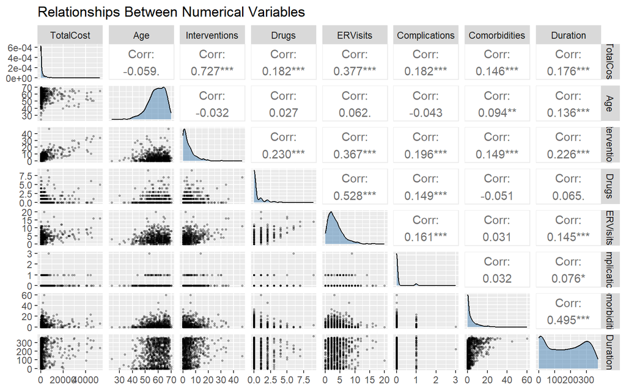

```r
# Create a matrix of plots for numerical variables
# We exclude ID and the categorical Gender for now
heart_data %>%
  select(TotalCost, Age, Interventions, Drugs, ERVisits,
         Complications, Comorbidities, Duration) %>%
  ggpairs(
    lower = list(continuous = wrap("points", alpha = 0.3, size=0.5)),
    diag = list(continuous = wrap("densityDiag", fill="#4682B4", alpha=0.5)),
    title = "Relationships Between Numerical Variables"
  )
```

For Categorical Variables

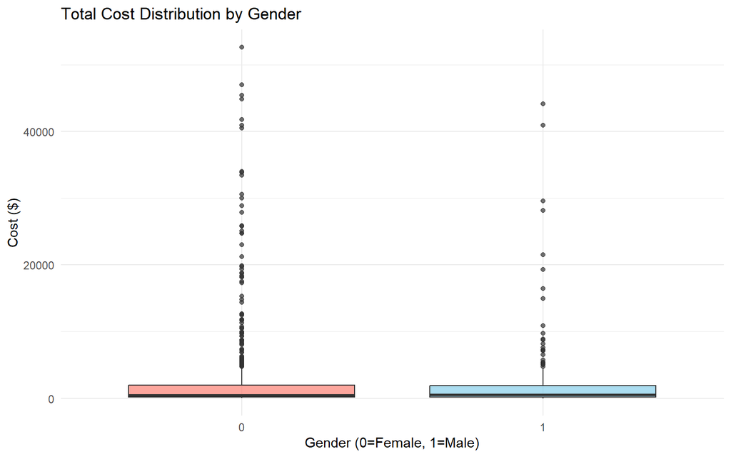

```r
# Boxplot of Cost by Gender
ggplot(heart_data, aes(x = factor(Gender), y = TotalCost, fill = factor(Gender))) +
  geom_boxplot(alpha = 0.7) +
  scale_fill_manual(values = c("salmon", "skyblue"), labels = c("Female", "Male")) +
  labs(title = "Total Cost Distribution by Gender", x = "Gender (0=Female, 1=Male)", y = "Cost ($)") +
  theme_minimal() +
  guides(fill = "none")
```

```r
# Fit the full linear model
# Y = TotalCost, X = all other variables except ID
model_full <- lm(TotalCost ~ . - ID, data = heart_data)

# Summary of the model
summary(model_full)
```

```
##
## Call:
## lm(formula = TotalCost ~ . - ID, data = heart_data)
##
## Residuals:
##    Min     1Q Median     3Q    Max
## -29642  -1640    -18   1272  36552
##
## Coefficients:
##                Estimate Std. Error t value Pr(>|t|)
## (Intercept)    653.8336  1422.2145   0.460   0.6458
## Age            -48.0149    24.1226  -1.990   0.0469 *
## Gender1       -906.5264   385.0864  -2.354   0.0188 *
## Interventions  800.2449    31.8848  25.098  < 2e-16 ***
## Drugs         -365.5217   178.8959  -2.043   0.0414 *
## ERVisits       422.4063    75.8315   5.570  3.5e-08 ***
## Complications  873.8176   665.0742   1.314   0.1893
## Comorbidities   51.7655    31.3016   1.654   0.0986 .
## Duration        -0.7467     1.5685  -0.476   0.6342
## ---
## Signif. codes:  0 '***' 0.001 '**' 0.01 '*' 0.05 '.' 0.1 ' ' 1
##
## Residual standard error: 4498 on 779 degrees of freedom
## Multiple R-squared:  0.5527, Adjusted R-squared:  0.5481
## F-statistic: 120.3 on 8 and 779 DF,  p-value: < 2.2e-16
```